# Choice of alpha metric

Natasa Mortvanski

2023-03-24

Here I gathered together all the tests I did on healthy samples and comparisons between healthy and disease samples with the aim of choosing the apropariate representative alpha metrics that are going to be used for final report.

```r
library(dplyr)
library(ggplot2)
library(plyr)
library(cowplot)
library(tibble)
library(flextable)
library(nortest)
library(corrplot)
library(PerformanceAnalytics)
library(RColorBrewer)
library(here)
library(ROSE)
library(randomForest)
library(caret)
library(rstatix)
library(gridExtra)
library(grid)
#install.packages("moments")
library(moments)
```

```r
metric <- c("chao1", "margalef", "menhinick", "fisher_alpha", "faith_pd", "gini_index", "strong", "pielou_evenness", "shannon_entropy", "simpson")
```

#Import data

```r
all_healthy <- read.csv(here("01_tidy_data", "AGP_healthy.csv.gz"), header = TRUE, sep = ",")
IBD <- read.csv(here("01_tidy_data", "IBD.csv.gz"), header = TRUE, sep = ",")
UC <- read.csv(here("01_tidy_data", "UC.csv.gz"), header = TRUE, sep = ",")
CD <- read.csv(here("01_tidy_data", "CD_2.csv.gz"), header = TRUE, sep = ",")
CDI <- read.csv(here("01_tidy_data", "ncbi_CDI.csv.gz"), header = TRUE, sep = ",")
hospital_CDI <- read.csv(here("01_tidy_data", "hosp_CDI.csv.gz"), header = TRUE, sep = ",")
hospital_donor <- read.csv(here("01_tidy_data", "hosp_donor.csv.gz"), header = TRUE, sep = ",")

all_healthy <- dplyr::select(all_healthy, sample_id, shannon_entropy, chao1, menhinick, margalef, fisher_alpha, simpson, pielou_evenness, gini_index, strong, simpson, faith_pd, condition)

CD_merge <- CD %>%
  filter(condition != "not applicable")

CD_merge$condition[CD_merge$condition=="control"] <- "healthy"
CD_merge$condition[CD_merge$condition=="crohns"] <- "CD"
```

Dataset combining all datasets:

```r
healthy_disease <- rbind.fill(all_healthy, IBD, UC, CD_merge, CDI)

# extract only allpha metrics and condition columns
healthy_disease <- dplyr::select(healthy_disease, shannon_entropy, chao1, menhinick, margalef, fisher_alpha, simpson, gini_index, strong, pielou_evenness, faith_pd, condition)

# for random forest
healthy_disease$healthy_or_not[healthy_disease$condition == "healthy"] <- "healthy"
healthy_disease$healthy_or_not[healthy_disease$condition != "healthy"] <- "unhealthy"

healthy_disease$healthy_or_not<- as.factor(healthy_disease$healthy_or_not)
healthy_disease$condition<- as.factor(healthy_disease$condition)

table(healthy_disease$condition)
```

```
##
##      CD     CDI healthy      UC
##     319      73    1823      40
```

```r
table(healthy_disease$healthy_or_not)
```

```
##
##   healthy unhealthy
##      1823       432
```

Dataset combining healthy samples and IBD samples:

```r
healthy_IBD <- rbind.fill(all_healthy, IBD, UC, CD_merge)

# extract only allpha metrics and condition columns
healthy_IBD <- dplyr::select(healthy_IBD, shannon_entropy, chao1, menhinick, margalef, fisher_alpha, simpson, gini_index, strong, pielou_evenness, faith_pd, condition)

# for random forest
healthy_IBD$healthy_or_not[healthy_IBD$condition == "healthy"] <- "healthy"
healthy_IBD$healthy_or_not[healthy_IBD$condition != "healthy"] <- "unhealthy"

healthy_IBD$healthy_or_not<- as.factor(healthy_IBD$healthy_or_not)
healthy_IBD$condition<- as.factor(healthy_IBD$condition)

table(healthy_IBD$condition)
```

```
##
##      CD healthy      UC
##     319    1823      40
```

```r
table(healthy_IBD$healthy_or_not)
```

```
##
##   healthy unhealthy
##      1823       359
```

Dataset combining healthy samples and CDI samples:

```r
healthy_CDI <- rbind.fill(all_healthy, CDI)

# extract only allpha metrics and condition columns
healthy_CDI <- dplyr::select(healthy_CDI, shannon_entropy, chao1, menhinick, margalef, fisher_alpha, simpson, gini_index, strong, pielou_evenness, faith_pd, condition)

# for random forest
healthy_CDI$healthy_or_not[healthy_CDI$condition == "healthy"] <- "healthy"
healthy_CDI$healthy_or_not[healthy_CDI$condition != "healthy"] <- "unhealthy"

healthy_CDI$healthy_or_not<- as.factor(healthy_CDI$healthy_or_not)
healthy_CDI$condition<- as.factor(healthy_CDI$condition)

table(healthy_CDI$condition)
```

```
##
##     CDI healthy
##      73    1470
```

```r
table(healthy_CDI$healthy_or_not)
```

```
##
##   healthy unhealthy
##      1470        73
```

```r
hospital_CDI_pre_FMT <- hospital_CDI %>%
  filter(FMT_pre_post == "pre")

compare_hospital <- rbind.fill(hospital_donor, hospital_CDI_pre_FMT)

compare_hospital$condition <- as.factor(compare_hospital$condition)

# Sizes of each dataset
table(compare_hospital$condition)
```

```
##
##       Cdif_pre healthy_donors
##             18            113
```

## Random forest classifier - feature importance

Lets create train and test subset of data for random forest classifier. We will also use train set as a subset of balanced number of healthy and unhealthy samples for effect size estimation:

```r
# Let's make training and testing subset of data
#make this example reproducible
set.seed(1)

#use 70% of dataset as training set and 30% as test set
sample <- sample(c(TRUE, FALSE), nrow(healthy_disease), replace=TRUE, prob=c(0.7,0.3))
train  <- healthy_disease[sample, ]
test   <- healthy_disease[!sample, ]

table(train$healthy_or_not)
```

```
##
##   healthy unhealthy
##      1277       304
```

```r
# condition groups are unbalanced. We will solve this by undersampling
under <- ovun.sample(healthy_or_not~., data=train, method = "under", p=0.5)
train <- under$data
table(train$healthy_or_not)
```

```
##
##   healthy unhealthy
##       290       304
```

```r
richness <- c("chao1", "margalef", "menhinick", "fisher_alpha", "faith_pd")
evenness <- c("gini_index", "strong", "pielou_evenness", "shannon_entropy", "simpson")
results_accuracy_all <- data.frame(model = character(0), accuracy = numeric(0) )

model_all_1 <- randomForest(condition ~ shannon_entropy + chao1 + menhinick + margalef + fisher_alpha + simpson + gini_index + strong + pielou_evenness + faith_pd, data = train, importance=TRUE)

model_all_2 <- randomForest(healthy_or_not ~ shannon_entropy + chao1 + menhinick + margalef + fisher_alpha + simpson + gini_index + strong + pielou_evenness + faith_pd, data = train, importance=TRUE)

prediction_all_1 <- predict(model_all_1, test)
confusion_matrix <- confusionMatrix(prediction_all_1, test$condition)
accuracy_all_model_1 <- confusion_matrix$overall["Accuracy"]

prediction_all_2 <- predict(model_all_2, test)
confusion_matrix <- confusionMatrix(prediction_all_2, test$healthy_or_not)
accuracy_all_model_2 <- confusion_matrix$overall["Accuracy"]

for (a in richness){
  for (b in evenness){
    formula_1 <- as.formula(sprintf("%s ~ %s + %s", "condition", a, b))
    model_1 <- randomForest(formula_1, data = train, importance=TRUE)

    formula_2 <- as.formula(sprintf("%s ~ %s + %s", "healthy_or_not", a, b))
    model_2 <- randomForest(formula_2, data = train, importance=TRUE)

    # Calculating accuracy
    prediction_1 <- predict(model_1, test)
    confusion_matrix <- confusionMatrix(prediction_1, test$condition)
    accuracy_1 <- confusion_matrix$overall["Accuracy"]

    prediction_2 <- predict(model_2, test)
    confusion_matrix <- confusionMatrix(prediction_2, test$healthy_or_not)
    accuracy_2 <- confusion_matrix$overall["Accuracy"]

    new_row <- c(model = sprintf("%s + %s", a, b), accuracy_condition = accuracy_1, accuracy_healthy_or_not = accuracy_2)
    results_accuracy_all <- rbind(results_accuracy_all, new_row)
  }
}

names(results_accuracy_all)[1] <- 'model'
names(results_accuracy_all)[2] <- 'accuracy_condition'
names(results_accuracy_all)[3] <- 'accuracy_healthy_or_not'

results_accuracy_all[nrow(results_accuracy_all)+1,] <- c("all alpha metrics", accuracy_all_model_1, accuracy_all_model_2)

results_accuracy_all$accuracy_condition <- as.numeric(results_accuracy_all$accuracy_condition)
results_accuracy_all$accuracy_healthy_or_not <- as.numeric(results_accuracy_all$accuracy_healthy_or_not)

results_accuracy_all <- results_accuracy_all[order(-results_accuracy_all$accuracy_condition),]

results_accuracy_all[1:10,] %>%
  flextable() %>%
  add_header_lines(values = "Accuracy of random forest classifier trained on all datasets in differnet models")
```

| Accuracy of random forest classifier trained on all datasets in differnet models model | Accuracy of random forest classifier trained on all datasets in differnet models accuracy_condition | Accuracy of random forest classifier trained on all datasets in differnet models accuracy_healthy_or_not |
| --- | --- | --- |
| all alpha metrics | 0.8783383 | 0.8887240 |
| faith_pd + gini_index | 0.8471810 | 0.8590504 |
| menhinick + gini_index | 0.8367953 | 0.8516320 |
| chao1 + gini_index | 0.8353116 | 0.8664688 |
| fisher_alpha + gini_index | 0.8293769 | 0.8531157 |
| margalef + gini_index | 0.8234421 | 0.8501484 |
| chao1 + pielou_evenness | 0.7195846 | 0.7433234 |
| chao1 + simpson | 0.7195846 | 0.7418398 |
| menhinick + strong | 0.7166172 | 0.7373887 |
| menhinick + pielou_evenness | 0.7136499 | 0.7329377 |

This table shows accuracy of random forest classifier trained on data set consisting of healthy and both IBD and CDI samples, using different models. We can see that the highest accuracy is obtained if all alpha metrics are used together. However, the decrease of accuracy is not substantial when we choose only two metrics (one representing richness metric and the other evenness metric). These are top ten models with highest accuracy. We can also see that classifier is slightly better at discriminating between healthy and unhealthy samples than at predicting specific condition category.

```r
# Let's make training and testing subset of data
#make this example reproducible
set.seed(1)

#use 70% of dataset as training set and 30% as test set
sample <- sample(c(TRUE, FALSE), nrow(healthy_IBD), replace=TRUE, prob=c(0.7,0.3))
train  <- healthy_IBD[sample, ]
test   <- healthy_IBD[!sample, ]

table(train$healthy_or_not)
```

```
##
##   healthy unhealthy
##      1277       249
```

```r
# condition groups are unbalanced. We will solve this by undersampling
under <- ovun.sample(healthy_or_not~., data=train, method = "under", p=0.5)
train <- under$data
table(train$healthy_or_not)
```

```
##
##   healthy unhealthy
##       236       249
```

```r
table(train$condition)
```

```
##
##      CD healthy      UC
##     225     236      24
```

```r
results_accuracy_IBD <- data.frame(model = character(0), accuracy_condition = numeric(0), accuracy_healthy_or_not = numeric(0) )

model_IBD_1 <- randomForest(condition ~ shannon_entropy + chao1 + menhinick + margalef + fisher_alpha + simpson + gini_index + strong + pielou_evenness + faith_pd, data = train, importance=TRUE)

model_IBD_2 <- randomForest(healthy_or_not ~ shannon_entropy + chao1 + menhinick + margalef + fisher_alpha + simpson + gini_index + strong + pielou_evenness + faith_pd, data = train, importance=TRUE)

prediction_IBD_1 <- predict(model_IBD_1, test)
confusion_matrix <- confusionMatrix(prediction_IBD_1, test$condition)
accuracy_IBD_model_1 <- confusion_matrix$overall["Accuracy"]

prediction_IBD_2 <- predict(model_IBD_2, test)
confusion_matrix <- confusionMatrix(prediction_IBD_2, test$healthy_or_not)
accuracy_IBD_model_2 <- confusion_matrix$overall["Accuracy"]

for (a in richness){
  for (b in evenness){
    formula_1 <- as.formula(sprintf("%s ~ %s + %s", "condition", a, b))
    model_1 <- randomForest(formula_1, data = train, importance=TRUE)

    formula_2 <- as.formula(sprintf("%s ~ %s + %s", "healthy_or_not", a, b))
    model_2 <- randomForest(formula_2, data = train, importance=TRUE)

    # Calculating accuracy
    prediction_1 <- predict(model_1, test)
    confusion_matrix <- confusionMatrix(prediction_1, test$condition)
    accuracy_1 <- confusion_matrix$overall["Accuracy"]

    prediction_2 <- predict(model_2, test)
    confusion_matrix <- confusionMatrix(prediction_2, test$healthy_or_not)
    accuracy_2 <- confusion_matrix$overall["Accuracy"]

    new_row <- c(model = sprintf("%s + %s", a, b), accuracy_condition = accuracy_1, accuracy_healthy_or_not = accuracy_2)
    results_accuracy_IBD <- rbind(results_accuracy_IBD, new_row)
  }
}

names(results_accuracy_IBD)[1] <- 'model'
names(results_accuracy_IBD)[2] <- 'accuracy_condition'
names(results_accuracy_IBD)[3] <- 'accuracy_healthy_or_not'

results_accuracy_IBD[nrow(results_accuracy_IBD)+1,] <- c("all alpha metrics", accuracy_IBD_model_1, accuracy_IBD_model_2)

results_accuracy_IBD$accuracy_condition <- as.numeric(results_accuracy_IBD$accuracy_condition)
results_accuracy_IBD$accuracy_healthy_or_not <- as.numeric(results_accuracy_IBD$accuracy_healthy_or_not)

results_accuracy_IBD <- results_accuracy_IBD[order(-results_accuracy_IBD$accuracy_condition),]

results_accuracy_IBD[1:10,] %>%
  flextable() %>%
  add_header_lines(values = "Accuracy of random forest classifier trained on IBD and healthy datasets in differnet models")
```

| Accuracy of random forest classifier trained on IBD and healthy datasets in differnet models model | Accuracy of random forest classifier trained on IBD and healthy datasets in differnet models accuracy_condition | Accuracy of random forest classifier trained on IBD and healthy datasets in differnet models accuracy_healthy_or_not |
| --- | --- | --- |
| all alpha metrics | 0.8673780 | 0.8765244 |
| faith_pd + gini_index | 0.8551829 | 0.8612805 |
| menhinick + gini_index | 0.8536585 | 0.8551829 |
| fisher_alpha + gini_index | 0.8384146 | 0.8567073 |
| margalef + gini_index | 0.8262195 | 0.8536585 |
| chao1 + gini_index | 0.8201220 | 0.8429878 |
| fisher_alpha + simpson | 0.6981707 | 0.6966463 |
| menhinick + pielou_evenness | 0.6966463 | 0.6935976 |
| chao1 + pielou_evenness | 0.6920732 | 0.6966463 |
| margalef + pielou_evenness | 0.6920732 | 0.6966463 |

```r
# Let's make training and testing subset of data
#make this example reproducible
set.seed(1)

#use 70% of dataset as training set and 30% as test set
sample <- sample(c(TRUE, FALSE), nrow(healthy_CDI), replace=TRUE, prob=c(0.7,0.3))
train  <- healthy_CDI[sample, ]
test   <- healthy_CDI[!sample, ]

table(train$condition)
```

```
##
##     CDI healthy
##      46    1033
```

```r
# condition groups are unbalanced. We will solve this by undersampling
under <- ovun.sample(condition~., data=train, method = "under", p=0.5)
train <- under$data
table(train$condition)
```

```
##
## healthy     CDI
##      48      46
```

```r
results_accuracy_CDI <- data.frame(model = character(0), accuracy = numeric(0))

model_all <- randomForest(condition ~ shannon_entropy + chao1 + menhinick + margalef + fisher_alpha + simpson + gini_index + strong + pielou_evenness + faith_pd, data = train, importance=TRUE)

prediction_CDI_all <- predict(model_all, test)
confusion_matrix <- confusionMatrix(prediction_CDI_all, test$condition)
accuracy_CDI_all <- confusion_matrix$overall["Accuracy"]

for (a in richness){
  for (b in evenness){
    formula <- as.formula(sprintf("%s ~ %s + %s", "condition", a, b))
    model <- randomForest(formula, data = train, importance=TRUE)

    # Calculating accuracy
    prediction <- predict(model, test)
    confusion_matrix <- confusionMatrix(prediction, test$condition)
    accuracy <- confusion_matrix$overall["Accuracy"]

    new_row <- c(model = sprintf("%s + %s", a, b), accuracy = accuracy)
    results_accuracy_CDI <- rbind(results_accuracy_CDI, new_row)
  }
}
```

[output not shown]

[output cut: 16 more lines]

[output not shown]

```r
names(results_accuracy_CDI)[1] <- 'model'
names(results_accuracy_CDI)[2] <- 'accuracy'

results_accuracy_CDI[nrow(results_accuracy_CDI)+1,] <- c("all alpha metrics", accuracy_CDI_all)

results_accuracy_CDI$accuracy <- as.numeric(results_accuracy_CDI$accuracy)

results_accuracy_CDI <- results_accuracy_CDI[order(-results_accuracy_CDI$accuracy),]

results_accuracy_CDI[1:10,] %>%
  flextable() %>%
  add_header_lines(values = "Accuracy of random forest classifier trained on CDI and healthy datasets in differnet models")
```

| Accuracy of random forest classifier trained on CDI and healthy datasets in differnet models model | Accuracy of random forest classifier trained on CDI and healthy datasets in differnet models accuracy |
| --- | --- |
| chao1 + gini_index | 1.0000000 |
| margalef + gini_index | 1.0000000 |
| menhinick + gini_index | 1.0000000 |
| fisher_alpha + gini_index | 1.0000000 |
| faith_pd + gini_index | 0.9870690 |
| faith_pd + strong | 0.9849138 |
| faith_pd + pielou_evenness | 0.9849138 |
| faith_pd + shannon_entropy | 0.9849138 |
| faith_pd + simpson | 0.9849138 |
| all alpha metrics | 0.9849138 |

This table shows the accuracy of random forest classifier trained on healthy and CDI datasets, using different model. What we can see is that this classifier seems to be able to determine the differences between healthy and CDI samples with almost 100% accuracy in various models. This is due to difference between healthy and CDI samples.

It seems that all models with Gini index perform the best in all three data sets. This is why Gini has the highest importance for this classifier.

```r
model <- randomForest(condition ~ shannon_entropy + chao1 + menhinick + margalef + fisher_alpha + simpson + gini_index + strong + pielou_evenness + faith_pd, data = healthy_disease, importance=TRUE)

importance(model)
```

```
##                         CD       CDI  healthy        UC MeanDecreaseAccuracy
## shannon_entropy   9.349125  4.978069 14.03881  7.341915             17.44752
## chao1            18.556950 12.884280 20.23054 14.154564             24.95543
## menhinick        19.903502 16.047569 19.46916  6.971446             23.74742
## margalef         12.595612  8.229099 14.89758 11.196645             17.65948
## fisher_alpha     12.828397  9.106958 14.39753  9.051272             17.79030
## simpson          16.721528  5.267564 21.33552  7.920132             29.72100
## gini_index      103.672310 57.982435 78.32941 64.041781            109.70764
## strong            5.104912  4.160279 23.34506  3.002655             25.75575
## pielou_evenness   6.461484  4.613604 17.32894  6.552318             21.90607
## faith_pd         10.085039 49.910831 24.65253 10.172649             40.07746
##                 MeanDecreaseGini
## shannon_entropy         36.07538
## chao1                   70.01595
## menhinick               72.99784
## margalef                47.19874
## fisher_alpha            47.77249
## simpson                 40.90064
## gini_index             247.18657
## strong                  43.80745
## pielou_evenness         34.65245
## faith_pd                92.11379
```

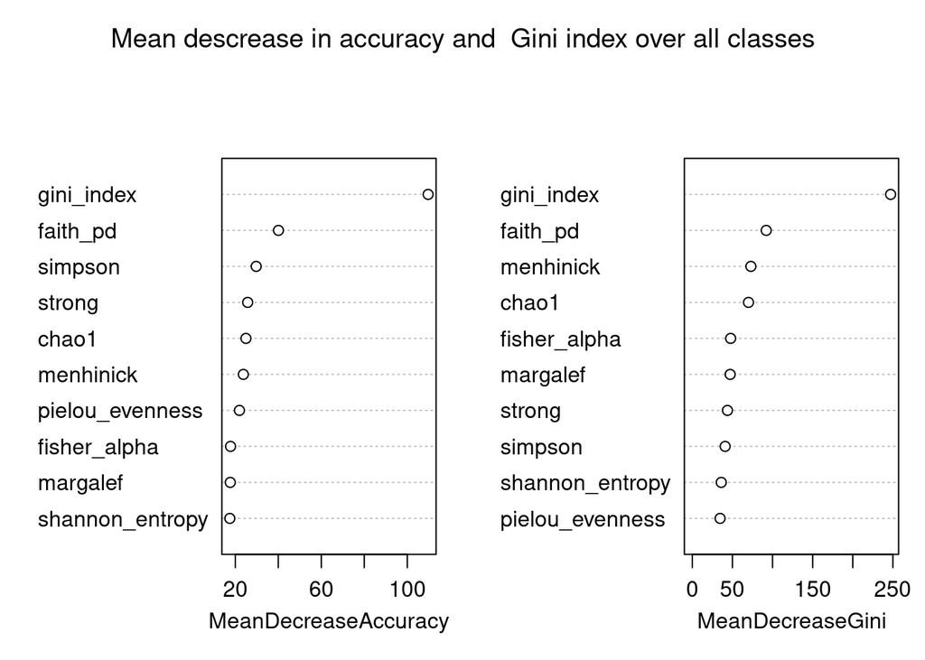

```r
varImpPlot(model, main= "Mean descrease in accuracy and  Gini index over all classes")
```

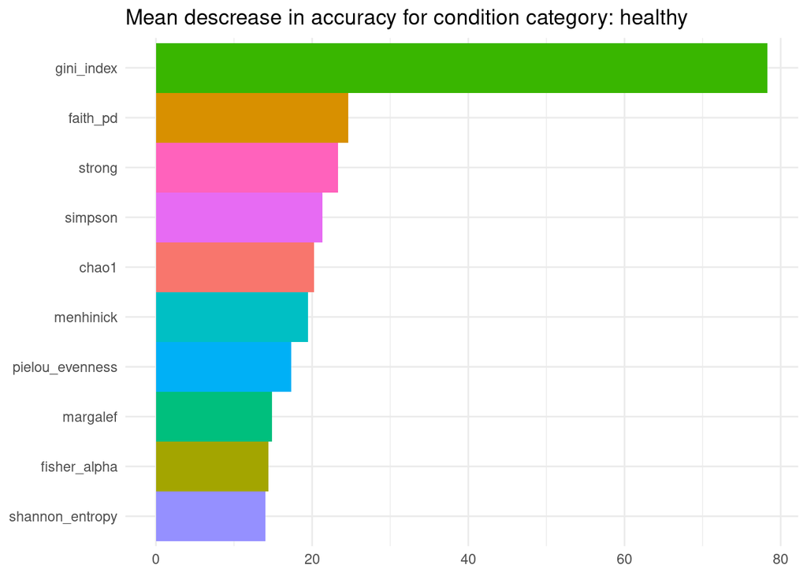

```r
#Conditional=True, adjusts for correlations between predictors.
i_scores <- caret::varImp(model, conditional = TRUE)

#Gathering rownames in 'var'  and converting it to the factor
#to provide 'fill' parameter for the bar chart.
i_scores <- i_scores %>% tibble::rownames_to_column("var")
i_scores$var<- i_scores$var %>% as.factor()

#Plotting the bar and polar charts for comparing variables
importance_plot <- i_scores %>% ggplot(aes(x = .data[["healthy"]], y=reorder(var, .data[["healthy"]]), fill = var)) +
  geom_bar(stat = "identity", show.legend = FALSE, width = 1) +
  labs(x = NULL, y = NULL, title ="Mean descrease in accuracy for condition category: healthy") +
  theme_minimal()

importance_plot
```

Hospital Clínic’s data:

```r
# Let's make training and testing subset of data
#make this example reproducible
set.seed(1)

#use 70% of dataset as training set and 30% as test set
sample <- sample(c(TRUE, FALSE), nrow(compare_hospital), replace=TRUE, prob=c(0.7,0.3))
train  <- compare_hospital[sample, ]
test   <- compare_hospital[!sample, ]

table(train$condition)
```

```
##
##       Cdif_pre healthy_donors
##             15             77
```

```r
table(test$condition)
```

```
##
##       Cdif_pre healthy_donors
##              3             36
```

```r
results_accuracy_CDI <- data.frame(model = character(0), accuracy = numeric(0))

model_all_hospital <- randomForest(condition ~ shannon_entropy + chao1 + menhinick + margalef + fisher_alpha + simpson + gini_index + strong + pielou_evenness + faith_pd, data = train, importance=TRUE)

prediction_CDI_all <- predict(model_all_hospital, test)
confusion_matrix <- confusionMatrix(prediction_CDI_all, test$condition)
accuracy_CDI_all <- confusion_matrix$overall["Accuracy"]

for (a in richness){
  for (b in evenness){
    formula <- as.formula(sprintf("%s ~ %s + %s", "condition", a, b))
    model <- randomForest(formula, data = train, importance=TRUE)

    # Calculating accuracy
    prediction <- predict(model, test)
    confusion_matrix <- confusionMatrix(prediction, test$condition)
    accuracy <- confusion_matrix$overall["Accuracy"]

    new_row <- c(model = sprintf("%s + %s", a, b), accuracy = accuracy)
    results_accuracy_CDI <- rbind(results_accuracy_CDI, new_row)
  }
}

names(results_accuracy_CDI)[1] <- 'model'
names(results_accuracy_CDI)[2] <- 'accuracy'

results_accuracy_CDI[nrow(results_accuracy_CDI)+1,] <- c("all alpha metrics", accuracy_CDI_all)

results_accuracy_CDI$accuracy <- as.numeric(results_accuracy_CDI$accuracy)

results_accuracy_CDI <- results_accuracy_CDI[order(-results_accuracy_CDI$accuracy),]

results_accuracy_CDI[1:10,] %>%
  flextable() %>%
  add_header_lines(values = "Accuracy of random forest classifier trained on CDI and healthy datasets in differnet models")
```

| Accuracy of random forest classifier trained on CDI and healthy datasets in differnet models model | Accuracy of random forest classifier trained on CDI and healthy datasets in differnet models accuracy |
| --- | --- |
| chao1 + gini_index | 1.000000 |
| margalef + gini_index | 1.000000 |
| menhinick + gini_index | 1.000000 |
| menhinick + strong | 1.000000 |
| menhinick + shannon_entropy | 1.000000 |
| fisher_alpha + gini_index | 1.000000 |
| faith_pd + gini_index | 1.000000 |
| all alpha metrics | 1.000000 |
| chao1 + strong | 0.974359 |
| menhinick + pielou_evenness | 0.974359 |

## Wilcoxon test and statistical power (HEALTHY vs UNHEALTHY)

```r
table(healthy_disease$healthy_or_not)
```

```
##
##   healthy unhealthy
##      1823       432
```

```r
test <- list()

tibble <- tibble()

for (i in 1:length(metric)){
  # Wilcoxon test
  test[[i]] <- pairwise.wilcox.test(healthy_disease[[metric[i]]], healthy_disease$healthy_or_not, p.adjust.method="none") %>%
  broom::tidy() %>% add_column(parameter = metric[i], .before='group1')
  test[[i]]$p.value <- round(test[[i]]$p.value, digits = 5)

  # Effect size
  tibble_a <- healthy_disease %>% wilcox_effsize(
    as.formula(sprintf("%s ~ %s", metric[i], "healthy_or_not")),
    ref.group = "healthy",
    paired = FALSE,
    alternative = "two.sided",
    ci = TRUE,
    conf.level = 0.95,
    ci.type = "perc",
    nboot = 1000
  )
  tibble <- bind_rows(tibble, tibble_a)
}

tests_1 <- do.call(what = rbind, args = test)

names(tibble)[names(tibble) == '.y.'] <- 'parameter'
eff_size <- tibble[, !names(tibble) %in% c("group1", "group2")]

tests_1 <- inner_join(tests_1, eff_size , by= "parameter")

test_1_show <- tests_1 %>%
  add_column(p.adjusted = round(p.adjust(tests_1$p.value, "fdr"), 5), .after='p.value') %>%
  arrange(-effsize)

test_1_show %>%
  flextable() %>%
  bold(~ p.value < 0.05, 4) %>%
  bold(~ p.adjusted < 0.05, 5) %>%
  add_header_lines(values = "Results of the Wilcox test for distributions of healthy vs unhealthy samples")
```

| Results of the Wilcox test for distributions of healthy vs unhealthy samples parameter | Results of the Wilcox test for distributions of healthy vs unhealthy samples group1 | Results of the Wilcox test for distributions of healthy vs unhealthy samples group2 | Results of the Wilcox test for distributions of healthy vs unhealthy samples p.value | Results of the Wilcox test for distributions of healthy vs unhealthy samples p.adjusted | Results of the Wilcox test for distributions of healthy vs unhealthy samples effsize | Results of the Wilcox test for distributions of healthy vs unhealthy samples n1 | Results of the Wilcox test for distributions of healthy vs unhealthy samples n2 | Results of the Wilcox test for distributions of healthy vs unhealthy samples conf.low | Results of the Wilcox test for distributions of healthy vs unhealthy samples conf.high | Results of the Wilcox test for distributions of healthy vs unhealthy samples magnitude |
| --- | --- | --- | --- | --- | --- | --- | --- | --- | --- | --- |
| gini_index | unhealthy | healthy | 0.00000 | 0.00000 | 0.55398188 | 1,823 | 432 | 0.53 | 0.58 | large |
| chao1 | unhealthy | healthy | 0.00000 | 0.00000 | 0.40001517 | 1,823 | 432 | 0.36 | 0.43 | moderate |
| menhinick | unhealthy | healthy | 0.00000 | 0.00000 | 0.37708963 | 1,823 | 432 | 0.34 | 0.41 | moderate |
| margalef | unhealthy | healthy | 0.00000 | 0.00000 | 0.37595431 | 1,823 | 432 | 0.34 | 0.41 | moderate |
| fisher_alpha | unhealthy | healthy | 0.00000 | 0.00000 | 0.37583316 | 1,823 | 432 | 0.34 | 0.41 | moderate |
| faith_pd | unhealthy | healthy | 0.00000 | 0.00000 | 0.30230189 | 1,823 | 432 | 0.26 | 0.34 | moderate |
| shannon_entropy | unhealthy | healthy | 0.00000 | 0.00000 | 0.24991471 | 1,823 | 432 | 0.21 | 0.28 | small |
| simpson | unhealthy | healthy | 0.00000 | 0.00000 | 0.18903170 | 1,823 | 432 | 0.15 | 0.23 | small |
| pielou_evenness | unhealthy | healthy | 0.00000 | 0.00000 | 0.13562516 | 1,823 | 432 | 0.10 | 0.17 | small |
| strong | unhealthy | healthy | 0.00223 | 0.00223 | 0.06440144 | 1,823 | 432 | 0.02 | 0.11 | small |

```r
#write.csv(tests_1, gzfile(here("03_plots_and_tables", "eff_size.csv")), row.names=FALSE)
#install.packages("writexl")
library(writexl)
write_xlsx(test_1_show, here("03_plots_and_tables", "eff_size.xlsx"))
```

Lets try calculating statistical power in a subset of data with equal number of healthy and unhealthy samples:

```r
set.seed(1)

#use 70% of dataset as training set and 30% as test set
sample <- sample(c(TRUE, FALSE), nrow(healthy_disease), replace=TRUE, prob=c(0.7,0.3))
train  <- healthy_disease[sample, ]
test   <- healthy_disease[!sample, ]

# condition groups are unbalanced. We will solve this by undersampling
under <- ovun.sample(healthy_or_not~., data=train, method = "under", p=0.5)
train <- under$data

test <- list()
tibble <- tibble()

for (i in 1:length(metric)){
  # Wilcoxon test
  test[[i]] <- pairwise.wilcox.test(train[[metric[i]]], train$healthy_or_not, p.adjust.method="none") %>%
  broom::tidy() %>% add_column(parameter = metric[i], .before='group1')
  test[[i]]$p.value <- round(test[[i]]$p.value, digits = 5)

  # Effect size
  tibble_a <- train %>% wilcox_effsize(
    as.formula(sprintf("%s ~ %s", metric[i], "healthy_or_not")),
    ref.group = "healthy",
    paired = FALSE,
    alternative = "two.sided",
    ci = TRUE,
    conf.level = 0.95,
    ci.type = "perc",
    nboot = 1000
  )
  tibble <- bind_rows(tibble, tibble_a)
}

tests_1b <- do.call(what = rbind, args = test)

names(tibble)[names(tibble) == '.y.'] <- 'parameter'
eff_size <- tibble[, !names(tibble) %in% c("group1", "group2")]

tests_alla <- inner_join(tests_1b, eff_size , by= "parameter")

tests_alla %>%
  add_column(p.adjusted = round(p.adjust(tests_alla$p.value, "fdr"),5), .after='p.value') %>%
  arrange(-effsize)  %>%
  flextable() %>%
  bold(~ p.value < 0.05, 4) %>%
  bold(~ p.adjusted < 0.05, 5) %>%
  add_header_lines(values = "Results of the Wilcox test for distributions of healthy vs unhealthy samples in balanced subset of data")
```

| Results of the Wilcox test for distributions of healthy vs unhealthy samples in balanced subset of data parameter | Results of the Wilcox test for distributions of healthy vs unhealthy samples in balanced subset of data group1 | Results of the Wilcox test for distributions of healthy vs unhealthy samples in balanced subset of data group2 | Results of the Wilcox test for distributions of healthy vs unhealthy samples in balanced subset of data p.value | Results of the Wilcox test for distributions of healthy vs unhealthy samples in balanced subset of data p.adjusted | Results of the Wilcox test for distributions of healthy vs unhealthy samples in balanced subset of data effsize | Results of the Wilcox test for distributions of healthy vs unhealthy samples in balanced subset of data n1 | Results of the Wilcox test for distributions of healthy vs unhealthy samples in balanced subset of data n2 | Results of the Wilcox test for distributions of healthy vs unhealthy samples in balanced subset of data conf.low | Results of the Wilcox test for distributions of healthy vs unhealthy samples in balanced subset of data conf.high | Results of the Wilcox test for distributions of healthy vs unhealthy samples in balanced subset of data magnitude |
| --- | --- | --- | --- | --- | --- | --- | --- | --- | --- | --- |
| gini_index | unhealthy | healthy | 0.00000 | 0.00000 | 0.67110602 | 290 | 304 | 0.62 | 0.72 | large |
| chao1 | unhealthy | healthy | 0.00000 | 0.00000 | 0.49080427 | 290 | 304 | 0.42 | 0.55 | moderate |
| menhinick | unhealthy | healthy | 0.00000 | 0.00000 | 0.47344904 | 290 | 304 | 0.40 | 0.54 | moderate |
| fisher_alpha | unhealthy | healthy | 0.00000 | 0.00000 | 0.46703172 | 290 | 304 | 0.40 | 0.54 | moderate |
| margalef | unhealthy | healthy | 0.00000 | 0.00000 | 0.46542248 | 290 | 304 | 0.39 | 0.53 | moderate |
| faith_pd | unhealthy | healthy | 0.00000 | 0.00000 | 0.37759894 | 290 | 304 | 0.31 | 0.45 | moderate |
| shannon_entropy | unhealthy | healthy | 0.00000 | 0.00000 | 0.32459261 | 290 | 304 | 0.25 | 0.40 | moderate |
| simpson | unhealthy | healthy | 0.00000 | 0.00000 | 0.25196158 | 290 | 304 | 0.17 | 0.33 | small |
| pielou_evenness | unhealthy | healthy | 0.00001 | 0.00001 | 0.18272562 | 290 | 304 | 0.11 | 0.26 | small |
| strong | unhealthy | healthy | 0.03645 | 0.03645 | 0.08583846 | 290 | 304 | 0.01 | 0.17 | small |

```r
test <- list()

tibble <- tibble()

for (i in 1:length(metric)){
  # Wilcoxon test
  test[[i]] <- pairwise.wilcox.test(compare_hospital[[metric[i]]], compare_hospital$condition, p.adjust.method="none") %>%
  broom::tidy() %>% add_column(parameter = metric[i], .before='group1')
  test[[i]]$p.value <- round(test[[i]]$p.value, digits = 5)

  # Effect size
  tibble_a <- compare_hospital %>% wilcox_effsize(
    as.formula(sprintf("%s ~ %s", metric[i], "condition")),
    ref.group = "healthy_donors",
    paired = FALSE,
    alternative = "two.sided",
    ci = TRUE,
    conf.level = 0.95,
    ci.type = "perc",
    nboot = 1000
  )
  tibble <- bind_rows(tibble, tibble_a)
}

tests_1 <- do.call(what = rbind, args = test)

names(tibble)[names(tibble) == '.y.'] <- 'parameter'
eff_size <- tibble[, !names(tibble) %in% c("group1", "group2")]

tests_1 <- inner_join(tests_1, eff_size , by= "parameter")

tests_1 %>%
  add_column(p.adjusted = round(p.adjust(tests_1$p.value, "fdr"), 5), .after='p.value') %>%
  arrange(-effsize)  %>%
  flextable() %>%
  bold(~ p.value < 0.05, 4) %>%
  bold(~ p.adjusted < 0.05, 5) %>%
  add_header_lines(values = "Results of the Wilcox test for distributions of healthy donors vs CDI samples from Hospital CLinic")
```

| Results of the Wilcox test for distributions of healthy donors vs CDI samples from Hospital CLinic parameter | Results of the Wilcox test for distributions of healthy donors vs CDI samples from Hospital CLinic group1 | Results of the Wilcox test for distributions of healthy donors vs CDI samples from Hospital CLinic group2 | Results of the Wilcox test for distributions of healthy donors vs CDI samples from Hospital CLinic p.value | Results of the Wilcox test for distributions of healthy donors vs CDI samples from Hospital CLinic p.adjusted | Results of the Wilcox test for distributions of healthy donors vs CDI samples from Hospital CLinic effsize | Results of the Wilcox test for distributions of healthy donors vs CDI samples from Hospital CLinic n1 | Results of the Wilcox test for distributions of healthy donors vs CDI samples from Hospital CLinic n2 | Results of the Wilcox test for distributions of healthy donors vs CDI samples from Hospital CLinic conf.low | Results of the Wilcox test for distributions of healthy donors vs CDI samples from Hospital CLinic conf.high | Results of the Wilcox test for distributions of healthy donors vs CDI samples from Hospital CLinic magnitude |
| --- | --- | --- | --- | --- | --- | --- | --- | --- | --- | --- |
| gini_index | healthy_donors | Cdif_pre | 0.00000 | 0.00000 | 0.5940370 | 113 | 18 | 0.48 | 0.69 | large |
| shannon_entropy | healthy_donors | Cdif_pre | 0.00000 | 0.00000 | 0.5823548 | 113 | 18 | 0.46 | 0.68 | large |
| chao1 | healthy_donors | Cdif_pre | 0.00000 | 0.00000 | 0.5636679 | 113 | 18 | 0.44 | 0.67 | large |
| faith_pd | healthy_donors | Cdif_pre | 0.00000 | 0.00000 | 0.5549018 | 113 | 18 | 0.43 | 0.66 | large |
| simpson | healthy_donors | Cdif_pre | 0.00000 | 0.00000 | 0.5519813 | 113 | 18 | 0.43 | 0.65 | large |
| margalef | healthy_donors | Cdif_pre | 0.00000 | 0.00000 | 0.5455961 | 113 | 18 | 0.42 | 0.64 | large |
| fisher_alpha | healthy_donors | Cdif_pre | 0.00000 | 0.00000 | 0.5269033 | 113 | 18 | 0.40 | 0.63 | large |
| pielou_evenness | healthy_donors | Cdif_pre | 0.00000 | 0.00000 | 0.5029163 | 113 | 18 | 0.36 | 0.61 | large |
| strong | healthy_donors | Cdif_pre | 0.00000 | 0.00000 | 0.4818884 | 113 | 18 | 0.31 | 0.61 | moderate |
| menhinick | healthy_donors | Cdif_pre | 0.00049 | 0.00049 | 0.3049263 | 113 | 18 | 0.11 | 0.46 | moderate |

## Wilcoxon test - CONDITIONS

```r
test <- list()

for (i in 1:length(metric)){
  test[[i]] <- pairwise.wilcox.test(healthy_disease[[metric[i]]], healthy_disease$condition, p.adjust.method="none") %>%
  broom::tidy() %>% add_column(parameter = metric[i], .before='group1')
  test[[i]]$p.value <- round(test[[i]]$p.value, digits = 5)
}

tests_2 <- do.call(what = rbind, args = test)

tests_2 %>%
  add_column(p.adjusted = round(p.adjust(tests_2$p.value, "fdr"),5), .after='p.value') %>%
  arrange(p.value)  %>%
  filter(group1=="healthy" | group2=="healthy") %>%
  flextable() %>%
  bold(~ p.value < 0.05, 4) %>%
  bold(~ p.adjusted < 0.05, 5) %>%
  add_header_lines(values = "Results of the Wilcox test for distributions of different conditions")
```

| Results of the Wilcox test for distributions of different conditions parameter | Results of the Wilcox test for distributions of different conditions group1 | Results of the Wilcox test for distributions of different conditions group2 | Results of the Wilcox test for distributions of different conditions p.value | Results of the Wilcox test for distributions of different conditions p.adjusted |
| --- | --- | --- | --- | --- |
| chao1 | healthy | CD | 0.00000 | 0.00000 |
| chao1 | healthy | CDI | 0.00000 | 0.00000 |
| chao1 | UC | healthy | 0.00000 | 0.00000 |
| margalef | healthy | CD | 0.00000 | 0.00000 |
| margalef | healthy | CDI | 0.00000 | 0.00000 |
| margalef | UC | healthy | 0.00000 | 0.00000 |
| menhinick | healthy | CD | 0.00000 | 0.00000 |
| menhinick | healthy | CDI | 0.00000 | 0.00000 |
| menhinick | UC | healthy | 0.00000 | 0.00000 |
| fisher_alpha | healthy | CD | 0.00000 | 0.00000 |
| fisher_alpha | healthy | CDI | 0.00000 | 0.00000 |
| fisher_alpha | UC | healthy | 0.00000 | 0.00000 |
| faith_pd | healthy | CD | 0.00000 | 0.00000 |
| faith_pd | healthy | CDI | 0.00000 | 0.00000 |
| faith_pd | UC | healthy | 0.00000 | 0.00000 |
| gini_index | healthy | CD | 0.00000 | 0.00000 |
| gini_index | healthy | CDI | 0.00000 | 0.00000 |
| gini_index | UC | healthy | 0.00000 | 0.00000 |
| strong | healthy | CD | 0.00000 | 0.00000 |
| pielou_evenness | healthy | CD | 0.00000 | 0.00000 |
| shannon_entropy | healthy | CD | 0.00000 | 0.00000 |
| shannon_entropy | healthy | CDI | 0.00000 | 0.00000 |
| simpson | healthy | CD | 0.00000 | 0.00000 |
| simpson | healthy | CDI | 0.00000 | 0.00000 |
| pielou_evenness | healthy | CDI | 0.00001 | 0.00001 |
| strong | UC | healthy | 0.00045 | 0.00060 |
| shannon_entropy | UC | healthy | 0.01719 | 0.02194 |
| pielou_evenness | UC | healthy | 0.19954 | 0.21379 |
| simpson | UC | healthy | 0.40888 | 0.42298 |
| strong | healthy | CDI | 0.95514 | 0.95514 |

## Comparing singe sample to healthy sample distribution with modified t-test

```r
set.seed(1)

#use 70% of dataset as healthy population and 30% as healthy samples to test
sample <- sample(c(TRUE, FALSE), nrow(all_healthy), replace=TRUE, prob=c(0.7,0.3))
healthy_popul  <- all_healthy[sample, ]
healthy_test   <- all_healthy[!sample, ]

nrow(healthy_popul)
```

```
## [1] 1033
```

```r
nrow(healthy_test)
```

```
## [1] 437
```

```r
# samples to test
test_samples <- rbind.fill(healthy_test, CDI)
test_samples$condition <- as.factor(test_samples$condition)
test_samples$condition <- relevel(test_samples$condition, "healthy")

#test_samples <- rbind.fill(healthy_popul, CDI)


nrow(test_samples)
```

```
## [1] 510
```

```r
library(table1)
CrawfordHowell <- function(case, control){
  tval <- (case - mean(control)) / (sd(control)*sqrt((length(control)+1) / length(control)))
  degfree <- length(control)-1
  pval <- pt(tval, df=degfree) #one-tailed T test
  result <- data.frame(t = tval, df = degfree, p=pval)
  return(result)
}

table_list <- list()
all_tables <- data.frame()

for (i in 1:length(metric)){

    t_statistics <- list()
    t_prob <- list()
    result <- data.frame()

    for (n in 1:nrow(test_samples)){
      result <- CrawfordHowell(test_samples[[metric[i]]][n], healthy_popul[[metric[i]]])
      t_statistics <- append(t_statistics, result[1])
      t_prob <- append(t_prob, result[3])
    }

    t_test_results <- test_samples[, c("sample_id", "condition")]
    t_test_results$metric <- test_samples[[metric[i]]]
    t_test_results$t_statistic <- unlist(t_statistics)
    t_test_results$t_probability <- unlist(t_prob)
    t_test_results$t_probability <- round(t_test_results$t_probability, digits=3)

    table_list[[i]] <- t_test_results

    all_tables_next <- data.frame(table1(~ t_probability | condition, data=t_test_results, overall=F, render.continuous=c("Mean (Min, Max)"="MEAN (MIN, MAX)")))
    all_tables <- rbind(all_tables, all_tables_next)
}

# Loop through each row of the merged data frame and add names of metrics

replacement_index <- 0

for (i in 1:nrow(all_tables)) {
  # Check if the value in the first column is "t_probability"
  if (all_tables[i, 1] == "t_probability") {
    # Calculate the index for replacement from the replacement list
    replacement_index <- replacement_index + 1
    # Substitute the value with the replacement value
    all_tables[i, 1] <- metric[replacement_index]
  }
}

rows_to_remove <- grepl("^\\(N\\=?", all_tables[,2])
rows_to_remove[1] <- FALSE
all_tables <- all_tables[!rows_to_remove, ]
```

```r
library(writexl)
write_xlsx(all_tables, here("03_plots_and_tables", "t_test.xlsx"))

all_tables %>% flextable()
```

| X. | healthy | CDI |
| --- | --- | --- |
|  | (N=437) | (N=73) |
| chao1 |  |  |
| Mean (Min, Max) | 0.477 (0.0130, 1.00) | 0.0262 (0.00500, 0.0820) |
| margalef |  |  |
| Mean (Min, Max) | 0.481 (0.00800, 1.00) | 0.0302 (0.00400, 0.116) |
| menhinick |  |  |
| Mean (Min, Max) | 0.481 (0.00800, 1.00) | 0.0253 (0.00400, 0.0930) |
| fisher_alpha |  |  |
| Mean (Min, Max) | 0.474 (0.0200, 1.00) | 0.0436 (0.0140, 0.122) |
| faith_pd |  |  |
| Mean (Min, Max) | 0.482 (0.00500, 0.999) | 0.00885 (0.00100, 0.0250) |
| gini_index |  |  |
| Mean (Min, Max) | 0.531 (0, 0.948) | 0 (0, 0) |
| strong |  |  |
| Mean (Min, Max) | 0.494 (0.0240, 0.999) | 0.480 (0.0160, 0.973) |
| pielou_evenness |  |  |
| Mean (Min, Max) | 0.520 (0, 0.915) | 0.405 (0.0110, 0.887) |
| shannon_entropy |  |  |
| Mean (Min, Max) | 0.511 (0, 0.965) | 0.180 (0.00300, 0.628) |
| simpson |  |  |
| Mean (Min, Max) | 0.536 (0, 0.792) | 0.371 (0.00100, 0.728) |

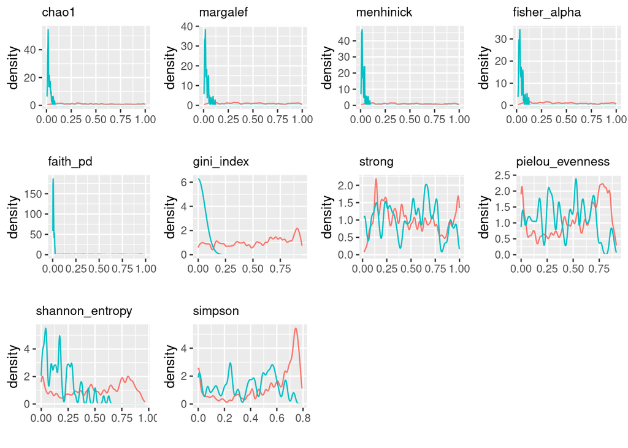

```r
p<- vector("list", length(metric))

for (i in 1:length(metric)){
p[[i]] <- ggplot(table_list[[i]], aes(x=t_probability, color=condition)) +
  #geom_histogram(stat="bin", bins=40, position=position_dodge())+
  geom_density( adjust = 1/6) +
  geom_hline(yintercept=0, colour="white", size=0.5) +
  ggtitle(metric[i])+
  theme(legend.position = "none", plot.title = element_text(size=10)) +
  xlab("")
}
grid.arrange(p[[1]], p[[2]], p[[3]], p[[4]], p[[5]], p[[6]],p[[7]], p[[8]],p[[9]], p[[10]], ncol=4)
```

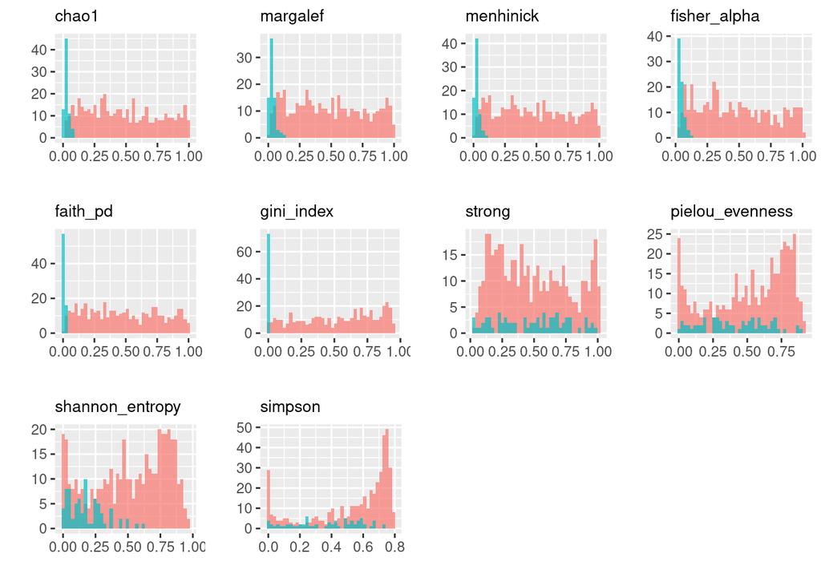

```r
p<- vector("list", length(metric))

for (i in 1:length(metric)){
p[[i]] <- ggplot(table_list[[i]], aes(x=t_probability, fill=condition)) +
  geom_histogram(stat="bin", bins=40, position= "identity", alpha=0.7)+
  #geom_density() +
  xlab("")+
  ylab("")+
  ggtitle(metric[i])+
  theme(legend.position = "none", plot.title = element_text(size=10)) +
  xlab("")+
  ylab("")+
  ggtitle(metric[i])
}

grid.arrange(p[[1]], p[[2]], p[[3]], p[[4]], p[[5]], p[[6]],p[[7]], p[[8]],p[[9]], p[[10]], ncol=4)
```

```r
mean_healthy <- mean(healthy_popul$strong)
SD_healthy <- sd(healthy_popul$strong)

t_statistics <- list()
t_prob <- list()

for (n in 1:nrow(test_samples)){
  x <- test_samples$strong[n]
  t_stat_x <- (x-mean_healthy)/(SD_healthy*sqrt((nrow(healthy_popul)+1)/nrow(healthy_popul)))
  t_statistics <- append(t_statistics, t_stat_x)
  t_prob_x <- pt(t_stat_x, df=nrow(healthy_popul)-1, lower.tail=FALSE)
  t_prob <- append(t_prob, t_prob_x)
}

t_test_results <- test_samples[, c("sample_id", "strong", "condition")]
t_test_results$t_statistic <- unlist(t_statistics)
t_test_results$t_probability <- unlist(t_prob)

table1(~ strong + t_probability | condition, data=t_test_results, caption = "Results for alpha metric: strong")
```

Results for alpha metric: strong

|  | healthy (N=437) | CDI (N=73) | Overall (N=510) |
| --- | --- | --- | --- |
| strong |  |  |  |
| Mean (SD) | 0.701 (0.0763) | 0.690 (0.0683) | 0.699 (0.0752) |
| Median [Min, Max] | 0.686 [0.547, 0.935] | 0.699 [0.534, 0.842] | 0.689 [0.534, 0.935] |
| t_probability |  |  |  |
| Mean (SD) | 0.506 (0.285) | 0.520 (0.272) | 0.508 (0.283) |
| Median [Min, Max] | 0.553 [0.000799, 0.976] | 0.486 [0.0273, 0.984] | 0.540 [0.000799, 0.984] |

## Hospital Clćnic’s data

```r
## First option - mix donor samples from CDI data set and stool donor data set and saple control population from this
set.seed(1)

all_healthy_donors <- rbind.fill(hospital_donor, hospital_CDI[hospital_CDI$condition=="donor",])
all_healthy_donors[all_healthy_donors == "healthy_donors"] <- 'donor'

#use 70% of dataset as healthy population and 30% as healthy samples to test
sample <- sample(c(TRUE, FALSE), nrow(hospital_donor), replace=TRUE, prob=c(0.7,0.3))
healthy_popul  <- hospital_donor[sample, ]
healthy_test   <- hospital_donor[!sample, ]

nrow(healthy_popul)
```

```
## [1] 77
```

```r
nrow(healthy_test)
```

```
## [1] 36
```

```r
# samples to test
test_samples <- rbind.fill(healthy_test, hospital_CDI[hospital_CDI$condition!="donor",])
test_samples[test_samples == "healthy_donors"] <- 'donor'

table(healthy_popul$condition)
```

```
##
## healthy_donors
##             77
```

```r
table(test_samples$condition)
```

```
##
## Cdif_post  Cdif_pre     donor
##        38        18        36
```

```r
nrow(test_samples)
```

```
## [1] 92
```

```r
# Second option - use stool biobank data set as control

healthy_popul <- hospital_donor
test_samples <- hospital_CDI
```

```r
# modified t-test for upper tail
CrawfordHowell_2 <- function(case, control){
  tval <- (case - mean(control)) / (sd(control)*sqrt((length(control)+1) / length(control)))
  degfree <- length(control)-1
  pval <- pt(tval, df=degfree, lower.tail=FALSE)
  result <- data.frame(t = tval, df = degfree, p=pval)
  return(result)
}

all_tables_2 <- data.frame()
table_list_2 <-  list()

for (i in 1:length(metric)){

    t_statistics <- list()
    t_prob <- list()
    result <- data.frame()

    for (n in 1:nrow(test_samples)){
      if(metric[i] != "gini_index" & metric[i] != "strong"){
        result <- CrawfordHowell(test_samples[[metric[i]]][n], healthy_popul[[metric[i]]])
      } else {
        result <- CrawfordHowell_2(test_samples[[metric[i]]][n], healthy_popul[[metric[i]]])
      }
      t_statistics <- append(t_statistics, result[1])
      t_prob <- append(t_prob, result[3])
    }

    t_test_results <- test_samples[, c("sample_id", "condition")]
    t_test_results$metric <- test_samples[[metric[i]]]
    t_test_results$t_statistic <- unlist(t_statistics)
    t_test_results$t_probability <- unlist(t_prob)
    t_test_results$t_probability <- round(t_test_results$t_probability, digits=3)

    table_list_2[[i]] <- t_test_results

    all_tables_next <- data.frame(table1(~ t_probability | condition, data=t_test_results, overall=F, render.continuous=c("Mean (Min, Max)"="MEAN (MIN, MAX)")))
    all_tables_2 <- rbind(all_tables_2, all_tables_next)
}

# Loop through each row of the merged data frame and add names of metrics

replacement_index <- 0

for (i in 1:nrow(all_tables_2)) {
  # Check if the value in the first column is "t_probability"
  if (all_tables_2[i, 1] == "t_probability") {
    # Calculate the index for replacement from the replacement list
    replacement_index <- replacement_index + 1
    # Substitute the value with the replacement value
    all_tables_2[i, 1] <- metric[replacement_index]
  }
}

rows_to_remove <- grepl(c("^\\(N\\=?"), all_tables_2[,2])
rows_to_remove[1] <- FALSE
all_tables_2 <- all_tables_2[!rows_to_remove, ]
```

```r
library(writexl)
write_xlsx(all_tables_2, here("03_plots_and_tables", "t_test_hospital.xlsx"))

all_tables_2 %>% flextable()
```

| X. | Cdif_post | Cdif_pre | donor |
| --- | --- | --- | --- |
|  | (N=38) | (N=18) | (N=38) |
| chao1 |  |  |  |
| Mean (Min, Max) | 0.206 (0, 0.995) | 0.0318 (0, 0.218) | 0.768 (0.0740, 1.00) |
| margalef |  |  |  |
| Mean (Min, Max) | 0.220 (0, 0.983) | 0.0440 (0, 0.328) | 0.814 (0.103, 1.00) |
| menhinick |  |  |  |
| Mean (Min, Max) | 0.523 (0.00100, 1.00) | 0.242 (0, 0.948) | 0.981 (0.662, 1.00) |
| fisher_alpha |  |  |  |
| Mean (Min, Max) | 0.263 (0.00100, 0.998) | 0.0623 (0, 0.430) | 0.867 (0.148, 1.00) |
| faith_pd |  |  |  |
| Mean (Min, Max) | 0.151 (0, 0.908) | 0.0567 (0, 0.315) | 0.770 (0.127, 0.999) |
| gini_index |  |  |  |
| Mean (Min, Max) | 0.000289 (0, 0.00300) | 0 (0, 0) | 0.0269 (0, 0.488) |
| strong |  |  |  |
| Mean (Min, Max) | 0.0904 (0, 0.888) | 0.0908 (0, 0.860) | 0.181 (0, 0.679) |
| pielou_evenness |  |  |  |
| Mean (Min, Max) | 0.0831 (0, 0.682) | 0.0782 (0, 0.650) | 0.391 (0.00300, 0.815) |
| shannon_entropy |  |  |  |
| Mean (Min, Max) | 0.0888 (0, 0.798) | 0.0108 (0, 0.0950) | 0.648 (0.0380, 1.00) |
| simpson |  |  |  |
| Mean (Min, Max) | 0.103 (0, 0.822) | 0.0411 (0, 0.395) | 0.694 (0.0310, 0.983) |

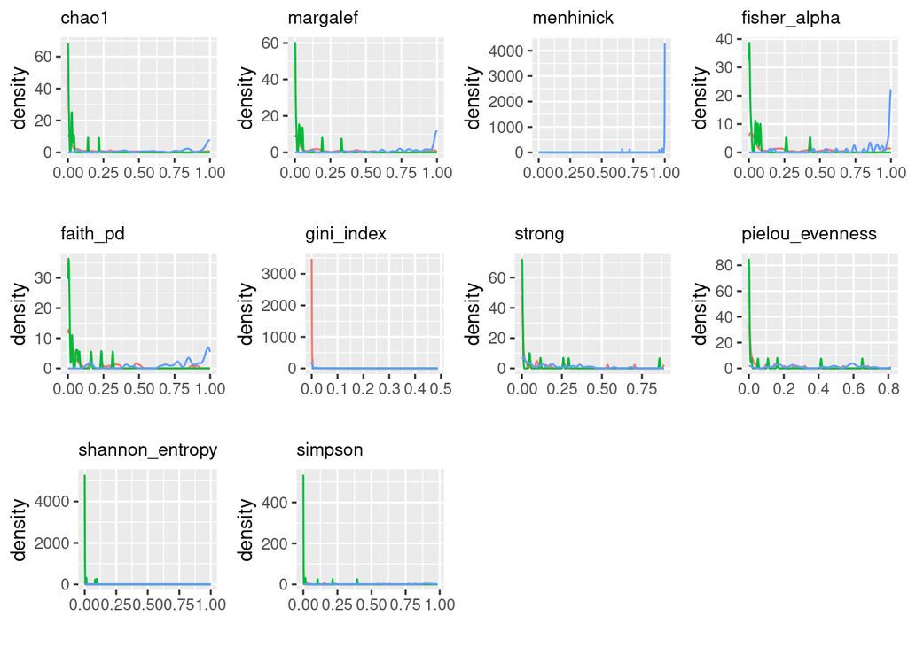

```r
p<- vector("list", length(metric))

for (i in 1:length(metric)){
p[[i]] <- ggplot(table_list_2[[i]], aes(x=t_probability, color=condition)) +
  geom_density(adjust = 1/6) +
  ggtitle(metric[i])+
  theme(legend.position = "none", plot.title = element_text(size=10)) +
  xlab("")
}

grid.arrange(p[[1]], p[[2]], p[[3]], p[[4]], p[[5]], p[[6]],p[[7]], p[[8]],p[[9]], p[[10]], ncol=4)
```

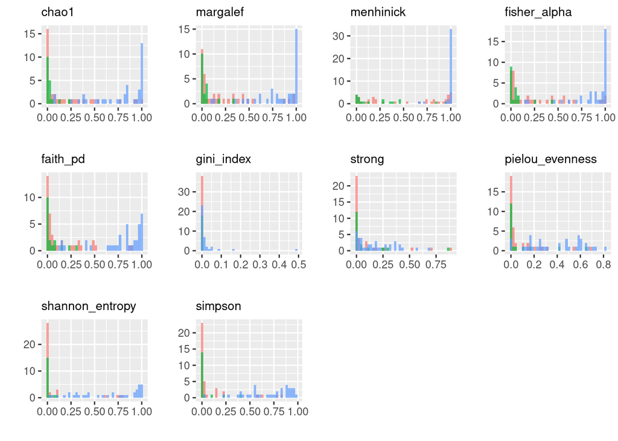

```r
p<- vector("list", length(metric))

for (i in 1:length(metric)){
p[[i]] <- ggplot(table_list_2[[i]], aes(x=t_probability, fill=condition)) +
  geom_histogram(stat="bin", bins=40, position= "identity", alpha=0.7)+
  #geom_density() +
  xlab("")+
  ylab("")+
  ggtitle(metric[i])+
  theme(legend.position = "none", plot.title = element_text(size=10)) +
  xlab("")+
  ylab("")+
  ggtitle(metric[i])
}

grid.arrange(p[[1]], p[[2]], p[[3]], p[[4]], p[[5]], p[[6]],p[[7]], p[[8]],p[[9]], p[[10]], ncol=4)
```

## Visualising the difference

### Gini vs Faith plot:

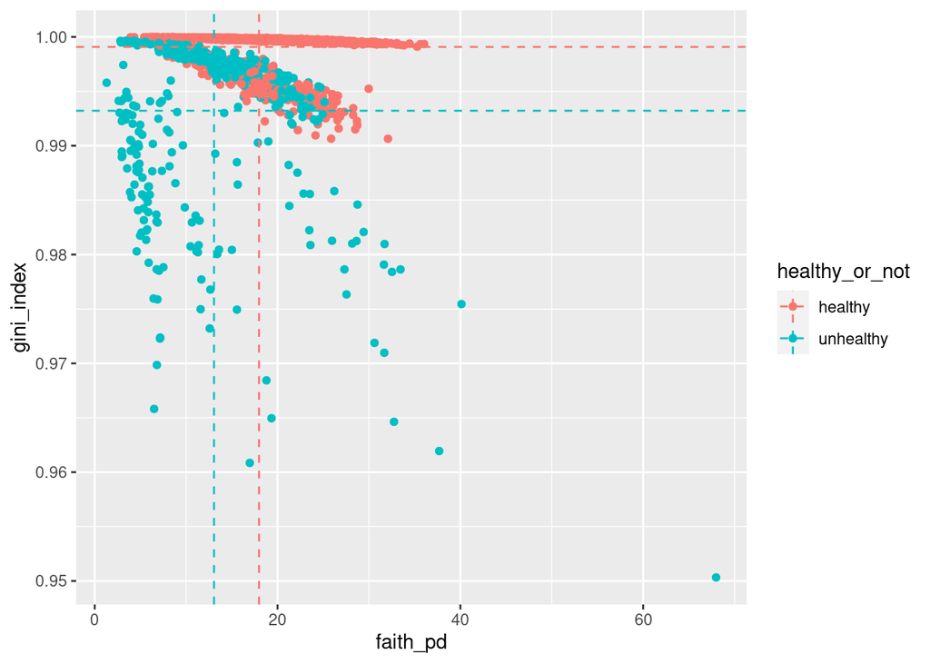

```r
mean_vline <- healthy_disease %>% dplyr::group_by(healthy_or_not) %>% dplyr::summarise(grp_mean_v = mean(faith_pd))
mean_hline <- healthy_disease %>% dplyr::group_by(healthy_or_not) %>% dplyr::summarise(grp_mean_h = mean(gini_index))

ggplot(healthy_disease, aes(faith_pd, gini_index)) + geom_jitter(aes(colour = healthy_or_not)) +
  geom_hline(data = mean_hline, aes(yintercept = grp_mean_h, color = healthy_or_not), linetype = "dashed") +
  geom_vline(data = mean_vline, aes(xintercept = grp_mean_v, color = healthy_or_not), linetype = "dashed")
```

### Gini vs Menhinick plot:

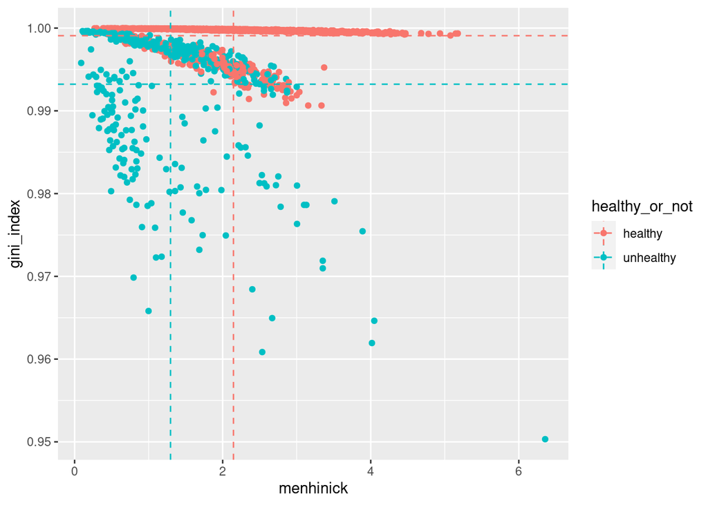

```r
mean_vline <- healthy_disease %>% dplyr::group_by(healthy_or_not) %>% dplyr::summarise(grp_mean_v = mean(menhinick))
mean_hline <- healthy_disease %>% dplyr::group_by(healthy_or_not) %>% dplyr::summarise(grp_mean_h = mean(gini_index))

ggplot(healthy_disease, aes(menhinick, gini_index)) + geom_jitter(aes(colour = healthy_or_not)) +
  geom_hline(data = mean_hline, aes(yintercept = grp_mean_h, color = healthy_or_not), linetype = "dashed") +
  geom_vline(data = mean_vline, aes(xintercept = grp_mean_v, color = healthy_or_not), linetype = "dashed")
```

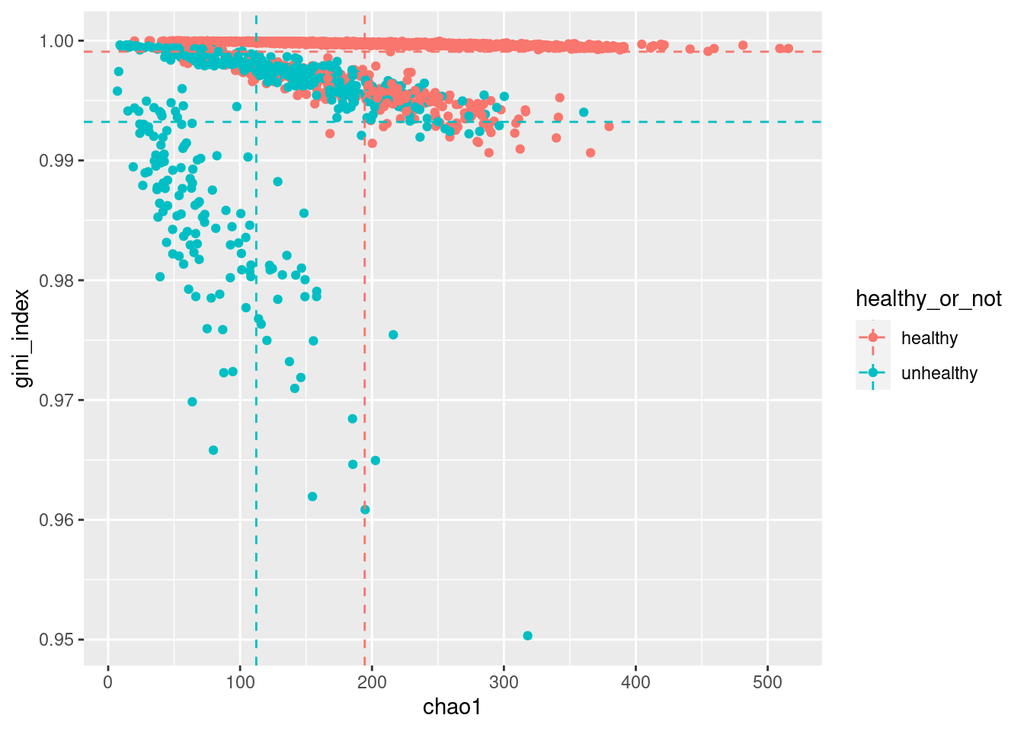

```r
mean_vline <- healthy_disease %>% dplyr::group_by(healthy_or_not) %>% dplyr::summarise(grp_mean_v = mean(chao1))
mean_hline <- healthy_disease %>% dplyr::group_by(healthy_or_not) %>% dplyr::summarise(grp_mean_h = mean(gini_index))

ggplot(healthy_disease, aes(chao1, gini_index)) + geom_jitter(aes(colour = healthy_or_not)) +
  geom_hline(data = mean_hline, aes(yintercept = grp_mean_h, color = healthy_or_not), linetype = "dashed") +
  geom_vline(data = mean_vline, aes(xintercept = grp_mean_v, color = healthy_or_not), linetype = "dashed")
```

### Manhinick vs Strong plot:

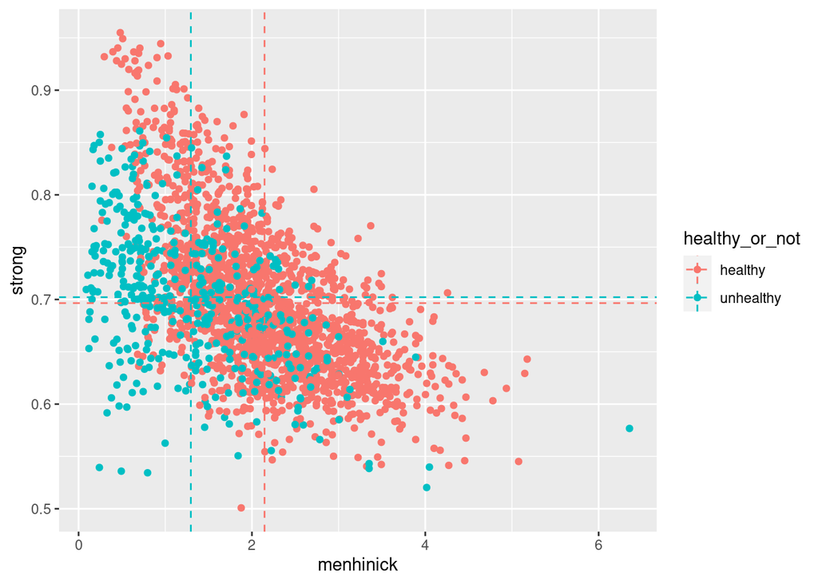

```r
mean_vline <- healthy_disease %>% dplyr::group_by(healthy_or_not) %>% dplyr::summarise(grp_mean_v = mean(menhinick))
mean_hline <- healthy_disease %>% dplyr::group_by(healthy_or_not) %>% dplyr::summarise(grp_mean_h = mean(strong))

ggplot(healthy_disease, aes(menhinick, strong)) + geom_jitter(aes(colour = healthy_or_not)) +
  geom_hline(data = mean_hline, aes(yintercept = grp_mean_h, color = healthy_or_not), linetype = "dashed") +
  geom_vline(data = mean_vline, aes(xintercept = grp_mean_v, color = healthy_or_not), linetype = "dashed")
```

### Margalef vs Strong plot:

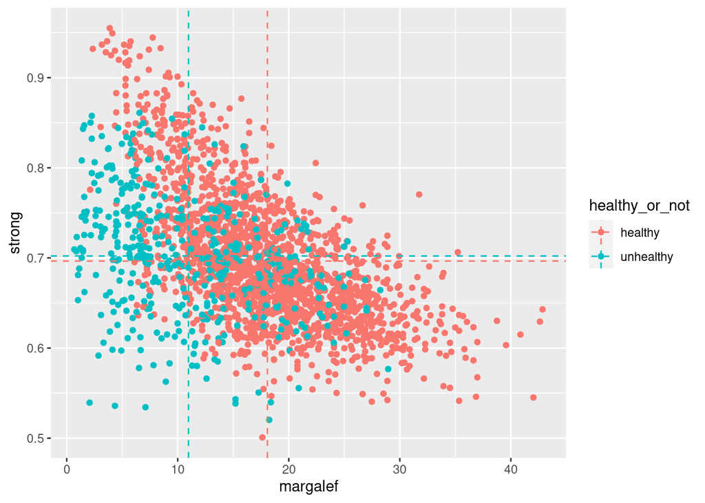

```r
mean_vline <- healthy_disease %>% dplyr::group_by(healthy_or_not) %>% dplyr::summarise(grp_mean_v = mean(margalef))
mean_hline <- healthy_disease %>% dplyr::group_by(healthy_or_not) %>% dplyr::summarise(grp_mean_h = mean(strong))

ggplot(healthy_disease, aes(margalef, strong)) + geom_jitter(aes(colour = healthy_or_not)) +
  geom_hline(data = mean_hline, aes(yintercept = grp_mean_h, color = healthy_or_not), linetype = "dashed") +
  geom_vline(data = mean_vline, aes(xintercept = grp_mean_v, color = healthy_or_not), linetype = "dashed")
```

### Faith vs Strong plot:

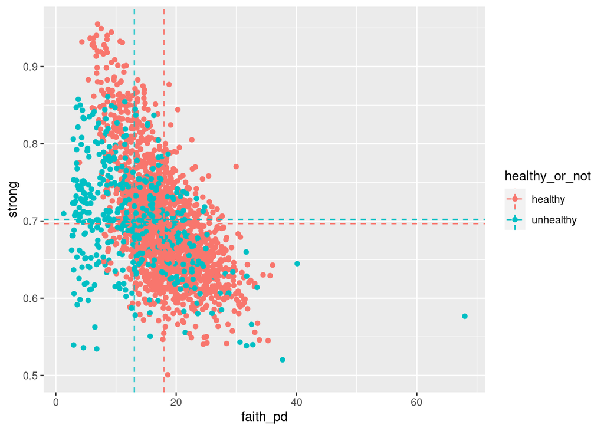

```r
mean_vline <- healthy_disease %>% dplyr::group_by(healthy_or_not) %>% dplyr::summarise(grp_mean_v = mean(faith_pd))
mean_hline <- healthy_disease %>% dplyr::group_by(healthy_or_not) %>% dplyr::summarise(grp_mean_h = mean(strong))

ggplot(healthy_disease, aes(faith_pd, strong)) + geom_jitter(aes(colour = healthy_or_not)) +
  geom_hline(data = mean_hline, aes(yintercept = grp_mean_h, color = healthy_or_not), linetype = "dashed") +
  geom_vline(data = mean_vline, aes(xintercept = grp_mean_v, color = healthy_or_not), linetype = "dashed")
```

### Manihinick vs Pielou plot:

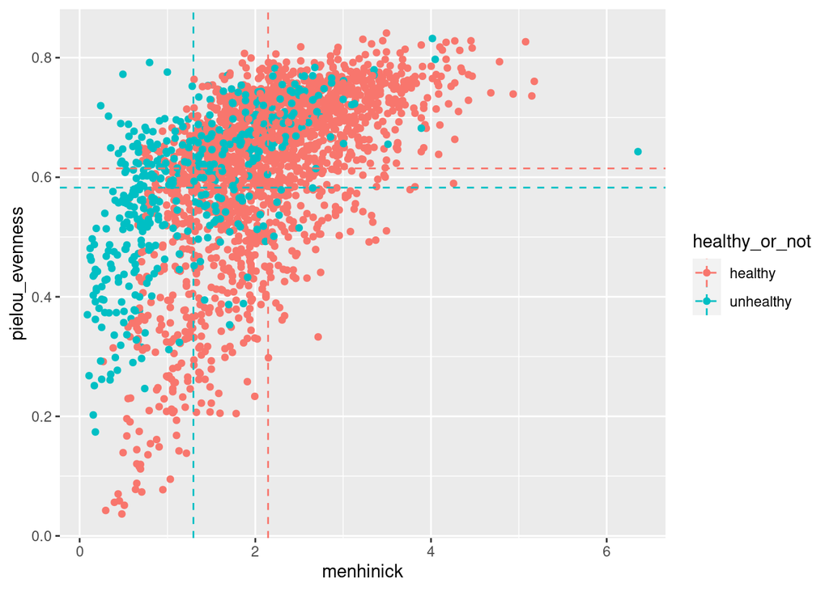

```r
mean_vline <- healthy_disease %>% dplyr::group_by(healthy_or_not) %>% dplyr::summarise(grp_mean_v = mean(menhinick))
mean_hline <- healthy_disease %>% dplyr::group_by(healthy_or_not) %>% dplyr::summarise(grp_mean_h = mean(pielou_evenness))

 ggplot(healthy_disease, aes(menhinick, pielou_evenness)) + geom_jitter(aes(colour = healthy_or_not)) +
   geom_hline(data = mean_hline, aes(yintercept = grp_mean_h, color = healthy_or_not), linetype = "dashed") +
   geom_vline(data = mean_vline, aes(xintercept = grp_mean_v, color = healthy_or_not), linetype = "dashed")
```

- Dominance (Strong) and evenness (Pielou) are complementary.